# Team A - Analysis Script

Douglas Lunnie, Nicholas Beliveau, Gabriella Evans, Cameron Stevens - December 2022

2022-12-13

# 1 Introduction -

The analysis team presents a general demographic overview of VIA’s market segmentation, their rate of laundry activity, and other findings of specific categories of interest. A Market Basket analysis was performed to evaluate common patterns of purchasing behavior among the data set.

Text descriptions of analyses are presented and a relevant as to the data package delivered ending October 16th 2022.

# 2 Demographic Rundown -

## 2.1 Evaluate VIA’s Segmentation Categories

While demographic distinctions weren’t strong between segment categories, there were some possible findings between laundry usage rates and loads per day when laundry was performed.

## 2.2 Segmentation Size Breakdown

As segmentation was a new feature with recent data, NA’s, or uncategoried respondents, are present and represent 37% of the entries. The NA’s were kept as a reminder that the segmentation data is only partially representative of the entire sample, and to maintain size context when evaluating differences between segments.

For example, “Avoident Apathetics” show some distinctions in laundry use rate behavior; which might allow more useful inferences, but Avoiders are 1.4% of the whole population.

Since the segmentation was a new feature of the data, it serves as an example of the challenges in data collection and structure. Consultancy between analyst, customer, ad survey taking may yeild stronger results in the future.

```
## # A tibble: 7 × 3
##   segment               Count Percent
##   <chr>                 <int>   <dbl>
## 1 AVOIDANT APATHETICS      94    1.37
## 2 ECO ESSENTIALIST        269    3.93
## 3 ANXIOUS STRIVERS        358    5.23
## 4 PASSIONATE OPTIMIZERS   538    7.86
## 5 INSECURE SHORTCUTTERS   627    9.16
## 6 MELLOW METHODICALS     2457   35.9
## 7 <NA>                   2499   36.5
```

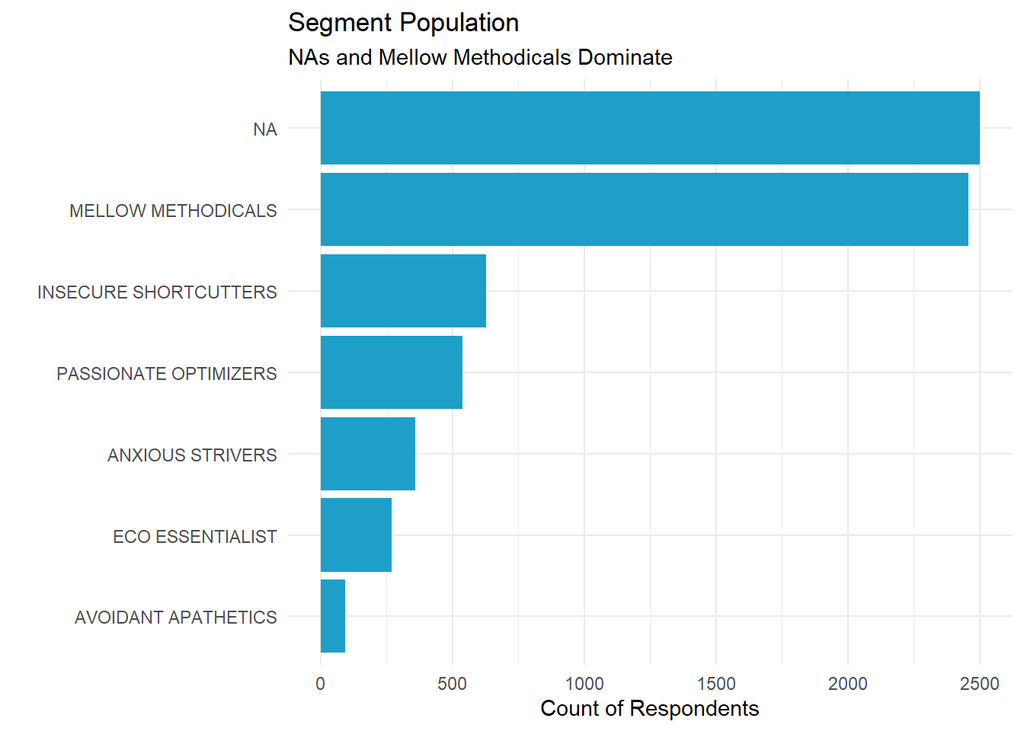

## 2.3 Segment Demograpic Patterns

Notable patterns are shared in the plots below. Initial analysis also looked at education, child count, and marital status comparisons between the Segments. No notable patterns were found for these demographic categories.

Age, Family Size and Income may be predictive of the Segments - plots are included below.

### 2.3.1 Segmentation - Age

Notable youth skew in Avoiders and Strivers; laundry optimization may be a skill developed with experience and by necessity.

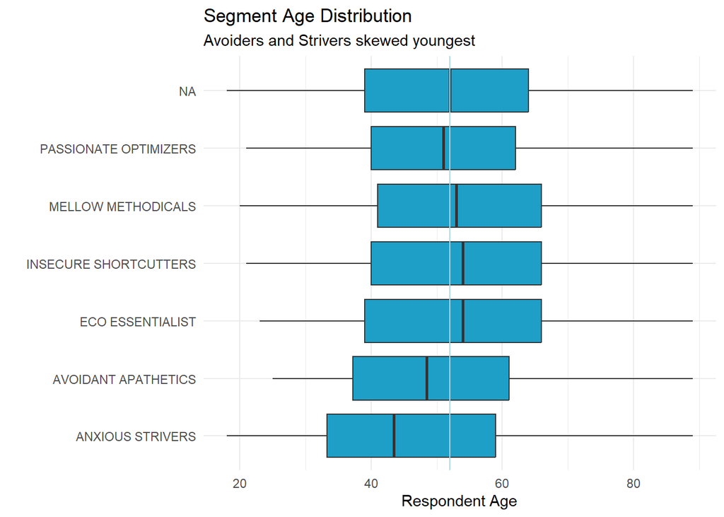

### 2.3.2 Segmentation - Family Size

Slightly higher mean family sizes for Optimizers and Strivers; which, may again indicate experience, necessity, and confidence level of the respondent.

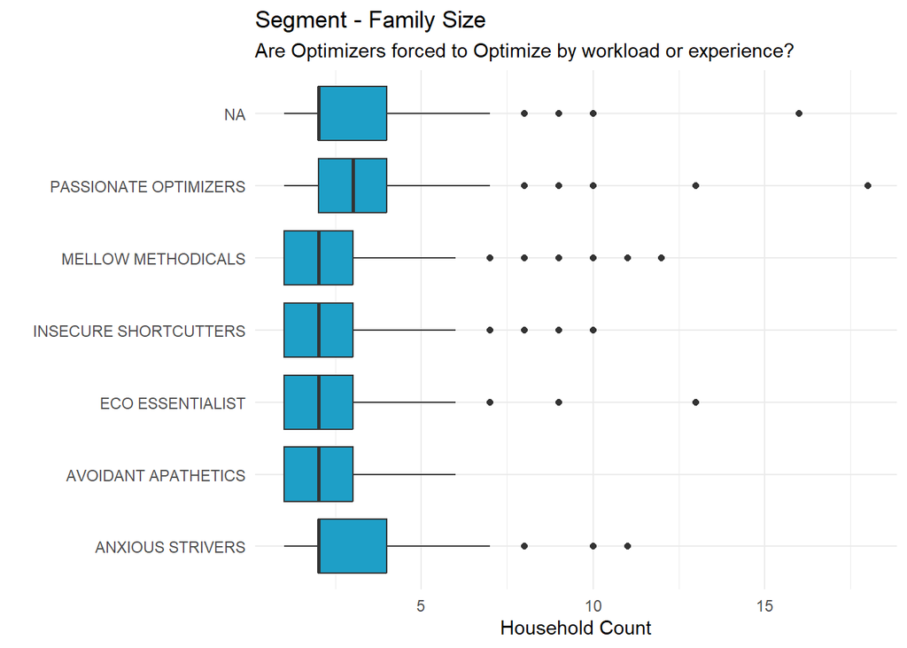

### 2.3.3 Segmentation - Income

Strivers are more likely to be low income, Eco minded skew more affluent. Other categories don’t appear proportionally different from the NA’s.

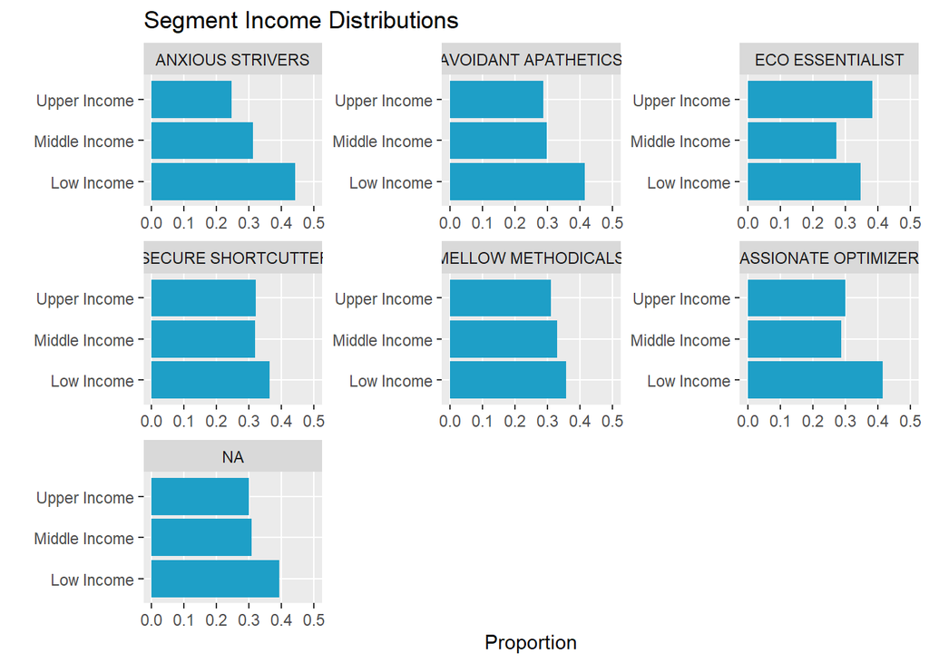

## 2.4 General Behavior of the Population - Laundry Event Frequency - All Households

More insight may be gained by exploring which populations perform laundry at different rates and how laundry activity is concentrated on days where laundry is performed. It’s notable here that there were numerous participants who engaged in multiple iterations of the study, almost half the participants participated for more than one week period.

### 2.4.1 Table - Event Counts per Day

2 events among the entire dataset had 9 loads of laundry.

```r
table(diary$Event_Count_Today)
```

```
##
##     1     2     3     4     5     6     7     8     9
## 32965  8706  2366   713   206    58    18     9     2
```

## 2.5 Laundry Use Stats -

### 2.5.1 Market Segmentation Laundry Use Rate.

Keeping in line with the segmentation, some more notable patterns emerge with behavior. This may mean that the respondent’s answer is indicative of how the household manages laundry, ranging from a fun activity, to a neutral task to manage, to a drudgery.

Behavior distinctions are evident with some of the segments, with Optimizers performing more often (0.5) and Avoiders less engaged (.38).

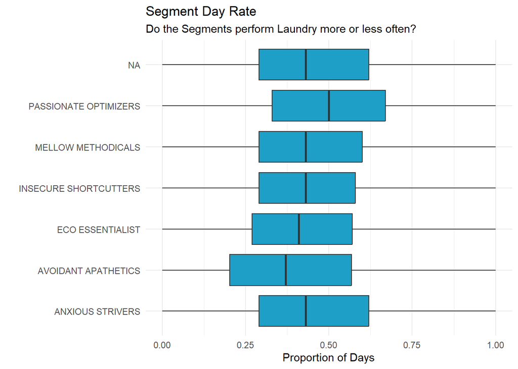

### 2.5.2 Market Segmentation - Loads per Day

Fewer distinctions for concentration of loads in a given day. It’s evident that Avoiders perform fewer loads on fewer days.

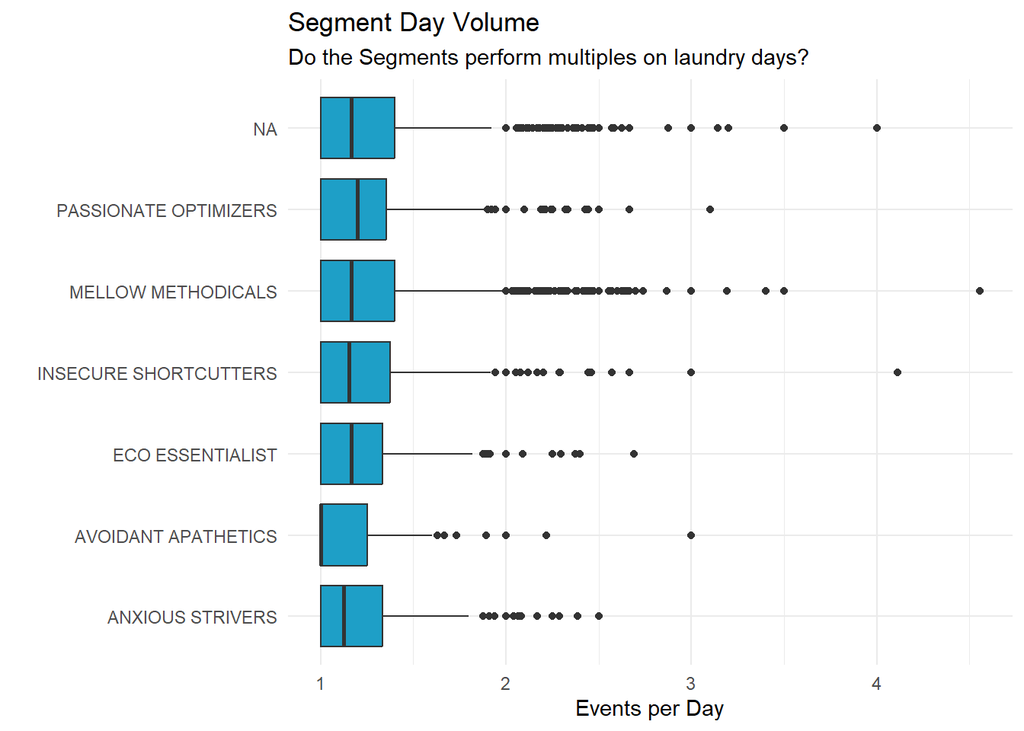

## 2.6 Age Cohorts - All Households - Is Age of Respondent vs. Head of Household?

We must ask if the survey respondent is generally representative of the Head of Household, or the “Laundry Authority” in the home. In all cases, the Interquartile Range, “IQR”, or the 50% about the mean, of the respondents falls neatly within the Head of Household age classification.

For most homes in the study, it’s safe to assume that the respondent is the Head of Household or their spouse.

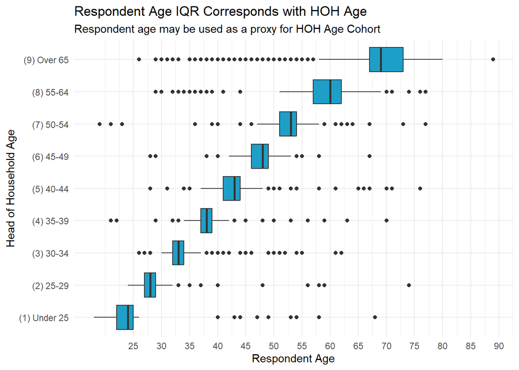

## 2.7 Age Distribution of Survey Respondents

Please Note the spike of respondents at aage 89, this is a data cleaning artifact, as “80+” was re coded as 89 years old. The sample likely tapers off like the younger end of the distribution.

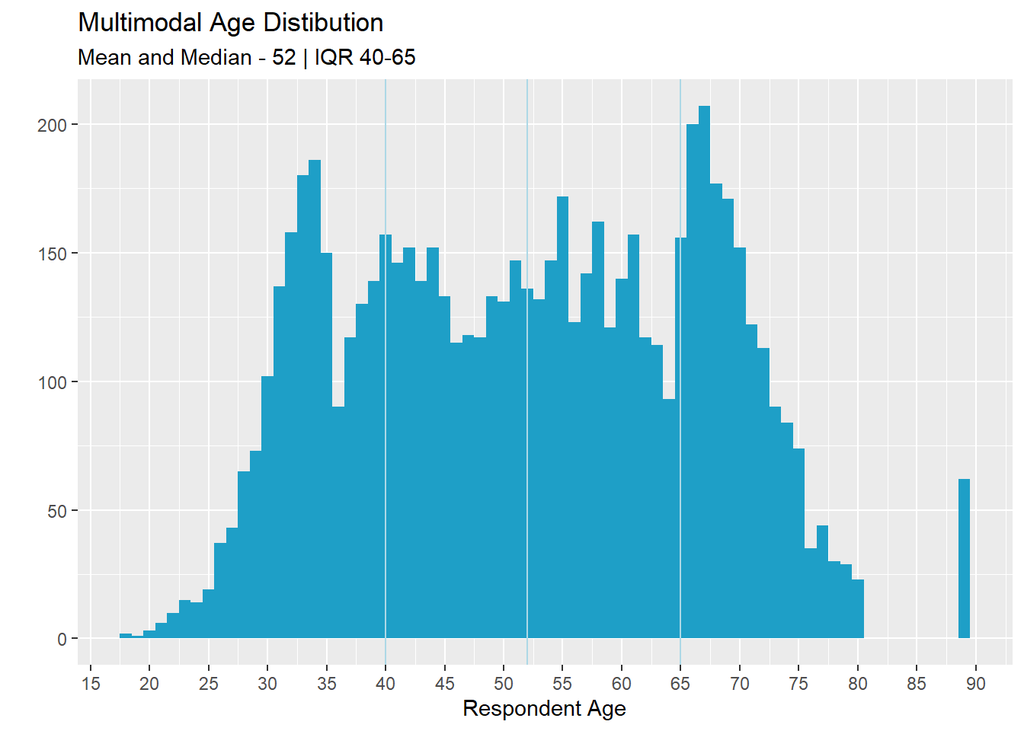

### 2.7.1 Under 40 Cohort

There was interest expressed in the laundry behavior of younger generations, selected here as respondents under 40 years old.

## 2.8 Age Cohort - Under 40

```
## # A tibble: 3 × 3
##   per_cap           n  freq
##   <chr>         <int> <dbl>
## 1 Low Income      735 0.401
## 2 Middle Income   700 0.382
## 3 Upper Income    399 0.218
```

### 2.8.1 Under 40 - Income Distribution

[figure not shown]

### 2.8.2 Under 40 - Marital Status

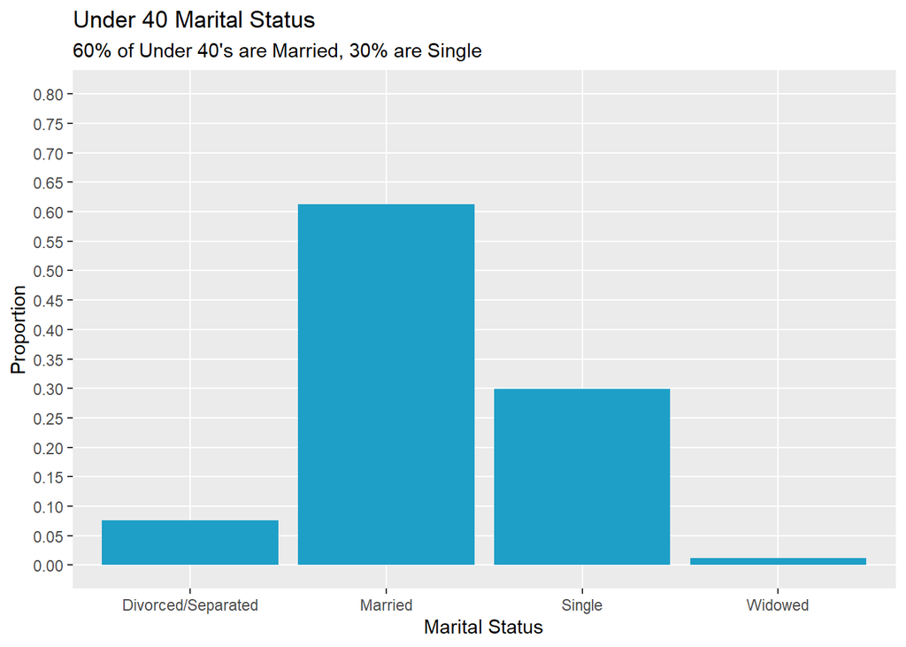

### 2.8.3 Under 40 - Own/Rent Frequency

A respondent owning or renting their home may indicate where the respondent is doing their laundry, either at home in an owned laundry room, in a shared laundry facility for a large apartment building, or at a laundromat. NA’s are still significant, 20% of the data. 43% own and 32% lease, while almost 4% report some other arrangement.

```
## # A tibble: 4 × 3
##   own_rent   Count Percentage
##   <chr>      <int>      <dbl>
## 1 Other         70       3.82
## 2 Own          799      43.6
## 3 Rent/lease   597      32.6
## 4 <NA>         368      20.1
```

### 2.8.4 Under 40s - Own/Rent Plot

[figure not shown]

### 2.8.5 Under 40s - Children

```
## # A tibble: 4 × 3
##   marital_code       Mean_Children SD_Children
##   <chr>                      <dbl>       <dbl>
## 1 Divorced/Separated         1.47        1.36
## 2 Married                    1.58        1.32
## 3 Single                     0.508       0.988
## 4 Widowed                    0.773       1.11
```

### 2.8.6 Laundry Events Histograms - All Respondents

“Proportion of Days” was a metric used to evaulate how often a respondent performed laundry during their survey period. For each respondent, all days were tallied for whether they did or did not perform laundry, and how many loads they performed each day when laundry was performed.

For example, a laundry frequency of 0.25 indicates that a household performed laundry for 1 in 4 of the days they reported, but does not indicate how many loads they did on a given day.

### 2.8.7 Laundry Frequency - All Households

In general, for the survey, laundry activity is performed on 46% of days.

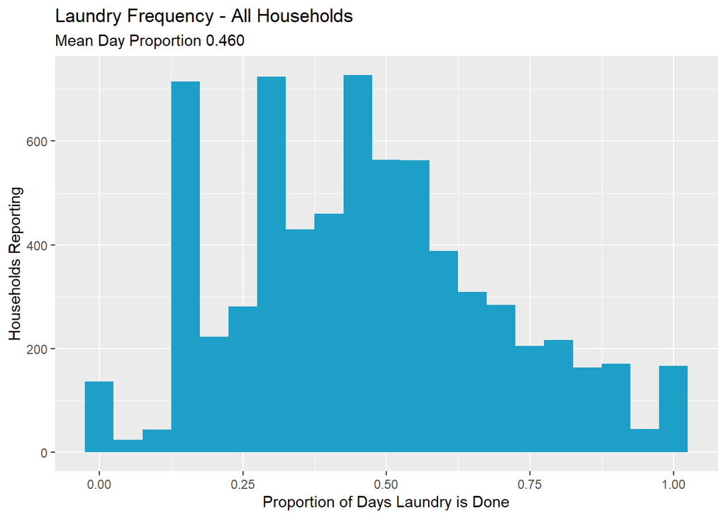

### 2.8.8 Laundry Frequency - Households with Children

Homes with children are doing laundry more often than the population, more than half the days.

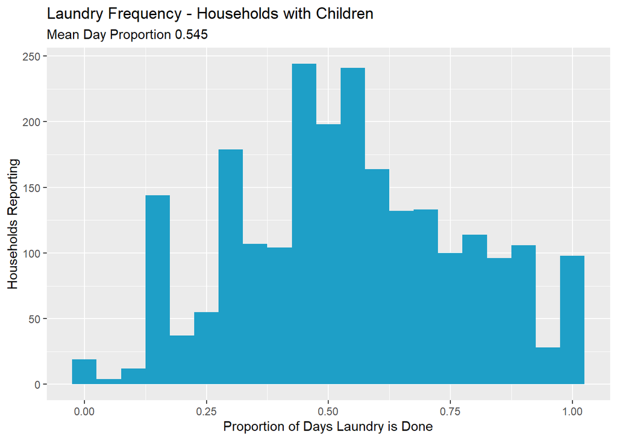

```
## [1] 0.5448898
```

### 2.8.9 Laundry Frequency - No Children

Homes without children are doing laundry less often than all households, or 41.6% of days.

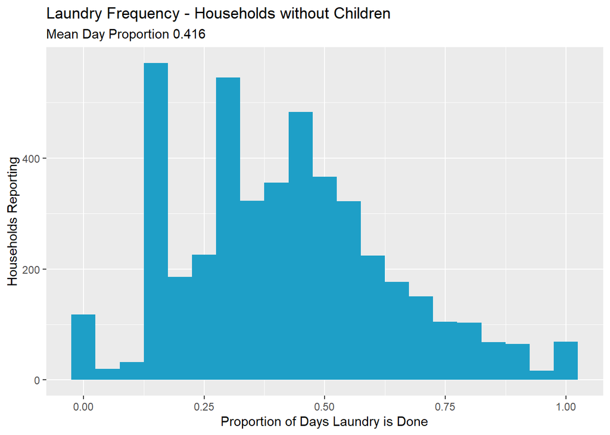

```
## [1] 0.4166821
```

# 3 Market Basket Analysis

### 3.0.1 Top 20 products by absolute numbers

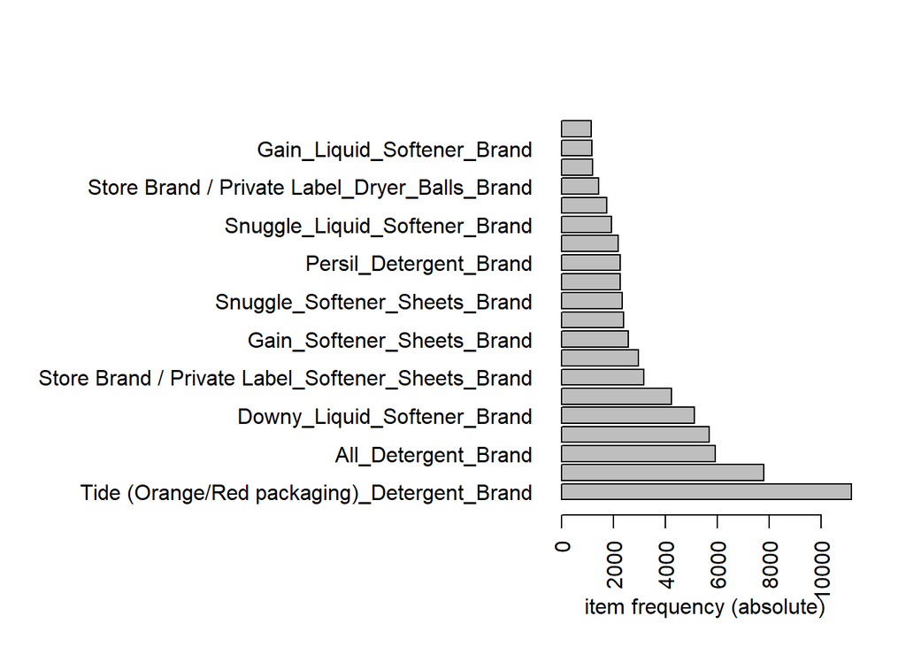

### 3.0.2 Top 20 products by proportions

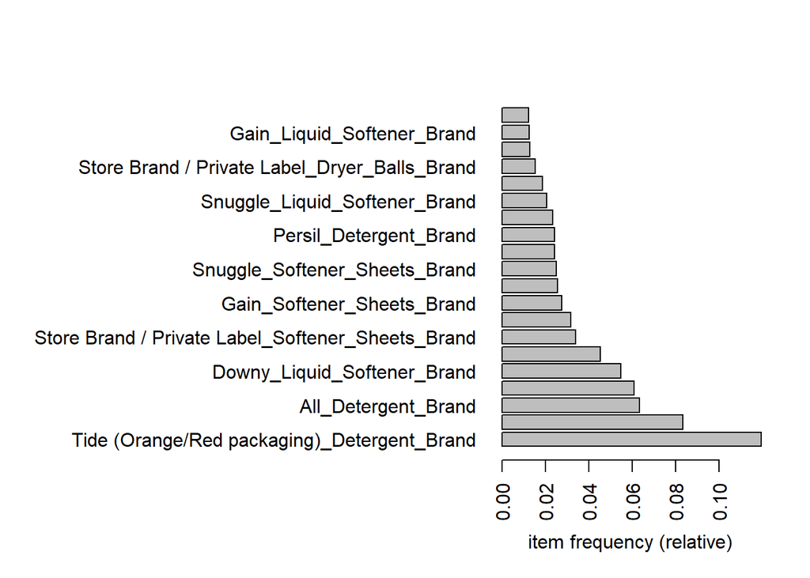

### 3.0.3 Check to see how many association rules the current settings have generated

```
## set of 36 rules
```

### 3.0.4 Preview the first 10 association rules generated

```
##      lhs                                                    rhs                                                      support confidence     coverage       lift count
## [1]  {Snuggle_Scent_Boost_Brand,
##       TruEarth_Detergent_Brand_Other}                    => {Store Brand / Private Label_Dryer_Balls_Brand}     0.0001067179  0.9090909 0.0001173897  59.321980    10
## [2]  {Store Brand / Private Label_Dryer_Balls_Brand,
##       TruEarth_Detergent_Brand_Other}                    => {Snuggle_Scent_Boost_Brand}                         0.0001067179  1.0000000 0.0001067179 173.527778    10
## [3]  {Downy_Dry_Clean_Sheet_Brand_Other,
##       Downy_Liquid_Softener_Brand}                       => {Tide (Orange/Red packaging)_Detergent_Brand}       0.0001067179  1.0000000 0.0001067179   8.386736    10
## [4]  {Earth breeze_Detergent_Brand_Other,
##       Store Brand / Private Label_Dryer_Balls_Brand}     => {Store Brand / Private Label_Softener_Sheets_Brand} 0.0001494050  1.0000000 0.0001494050  29.476250    14
## [5]  {Earth breeze_Detergent_Brand_Other,
##       Store Brand / Private Label_Softener_Sheets_Brand} => {Store Brand / Private Label_Dryer_Balls_Brand}     0.0001494050  0.9333333 0.0001600768  60.903900    14
## [6]  {Downy_Softener_Sheets_Brand,
##       ecoigy_Dryer_Balls_Brand_Other}                    => {Downy_Liquid_Softener_Brand}                       0.0002881383  0.9642857 0.0002988101  17.627466    27
## [7]  {Downy_Liquid_Softener_Brand,
##       ecoigy_Dryer_Balls_Brand_Other}                    => {Downy_Softener_Sheets_Brand}                       0.0002881383  1.0000000 0.0002881383  77.570364    27
## [8]  {Downy_Softener_Sheets_Brand,
##       ecoigy_Dryer_Balls_Brand_Other}                    => {Tide (Orange/Red packaging)_Detergent_Brand}       0.0002881383  0.9642857 0.0002988101   8.087210    27
## [9]  {ecoigy_Dryer_Balls_Brand_Other,
##       Tide (Orange/Red packaging)_Detergent_Brand}       => {Downy_Softener_Sheets_Brand}                       0.0002881383  1.0000000 0.0002881383  77.570364    27
## [10] {Downy_Liquid_Softener_Brand,
##       ecoigy_Dryer_Balls_Brand_Other}                    => {Tide (Orange/Red packaging)_Detergent_Brand}       0.0002881383  1.0000000 0.0002881383   8.386736    27
```

### 3.0.5 Top 10 association rules by Lift

```
##      lhs                                                    rhs                                                  support confidence     coverage      lift count
## [1]  {Method_Softener_Sheets_Brand_Other,
##       Tide (Orange/Red packaging)_Detergent_Brand}       => {Grove Co_Dryer_Balls_Brand}                    0.0001173897  1.0000000 0.0001173897 405.64935    11
## [2]  {Store Brand / Private Label_Dryer_Balls_Brand,
##       TruEarth_Detergent_Brand_Other}                    => {Snuggle_Scent_Boost_Brand}                     0.0001067179  1.0000000 0.0001067179 173.52778    10
## [3]  {Ariel_Detergent_Brand_Other,
##       Store Brand / Private Label_Softener_Sheets_Brand} => {Suavitel_Liquid_Softener_Brand}                0.0001280615  0.8571429 0.0001494050  82.80265    12
## [4]  {Downy_Liquid_Softener_Brand,
##       ecoigy_Dryer_Balls_Brand_Other}                    => {Downy_Softener_Sheets_Brand}                   0.0002881383  1.0000000 0.0002881383  77.57036    27
## [5]  {ecoigy_Dryer_Balls_Brand_Other,
##       Tide (Orange/Red packaging)_Detergent_Brand}       => {Downy_Softener_Sheets_Brand}                   0.0002881383  1.0000000 0.0002881383  77.57036    27
## [6]  {Downy_Liquid_Softener_Brand,
##       ecoigy_Dryer_Balls_Brand_Other,
##       Tide (Orange/Red packaging)_Detergent_Brand}       => {Downy_Softener_Sheets_Brand}                   0.0002881383  1.0000000 0.0002881383  77.57036    27
## [7]  {Gain_Detergent_Brand,
##       OxiClean_Sanitizer_Brand}                          => {Gain_Scent_Boost_Brand}                        0.0001280615  0.8000000 0.0001600768  77.28247    12
## [8]  {Earth breeze_Detergent_Brand_Other,
##       Store Brand / Private Label_Softener_Sheets_Brand} => {Store Brand / Private Label_Dryer_Balls_Brand} 0.0001494050  0.9333333 0.0001600768  60.90390    14
## [9]  {Snuggle_Scent_Boost_Brand,
##       TruEarth_Detergent_Brand_Other}                    => {Store Brand / Private Label_Dryer_Balls_Brand} 0.0001067179  0.9090909 0.0001173897  59.32198    10
## [10] {All_Detergent_Brand,
##       OxiClean_Sanitizer_Brand}                          => {Snuggle_Liquid_Softener_Brand}                 0.0001067179  0.8333333 0.0001280615  40.35530    10
```

[output not shown]

### 3.0.7 HTML Widget allowing visual exploration of rules & their interconnected-ness

[interactive chart not shown]

# 4 Sentiment Evaluations

Simple keyword matching was performed to capture counts and sample text entered related to respondent frustrations. Distinct categories were selected based on a sampling of some of the comments reviewed. Categories include frustrations related to People, Chores, Soils, and those without frustrations.

Simple Keyword selection is a crude analysis tool. Counting entries where keywords exists will not capture context, sarcasm, mis-spellings, double-negatives or other grammatical idiosyncrasies.

A random sample from each category is presented to provide the “flavor” of each complaint. Note the re-execution of the script will result in a new random sample.

## 4.1 Frustrations Related to Other People

219 Comments related to other people, selected to capture any entries with the following keywords:

“husband”, “son”, “wife”, “daughter”, “mother”, “father”, “sister”, “brother”, “spouse”, “sibling”, “kid”, “kids”, “shar.”, “people”

## 4.2 Random Sample - 10 People Frustrations

```
##  [1] "18 year old son not pretreating stains"
##  [2] "her personal support workers never seem to help with the laundry"
##  [3] "Common shared laundry room and others monopolizing available machines by leaving laundry after completed cycle."
##  [4] "My son leaving stuff in the washer or dryer."
##  [5] "My wife leaves her dirty clothes everywhere and hardly does laundry. ."
##  [6] "Having to check kids pockets"
##  [7] "Armpit stains in sons shirts"
##  [8] "Getting my son to do it because I can't"
##  [9] "Reminding my son to empty the lint basket after each use."
## [10] "Other people not removing their items in a timely manner."
```

## 4.3 Frustrations Related to Specific Tasks

1394 Comments related to task/chores, too many to print below. 745 (53%) include complaints including the word “time”, which may mean that half the pain of laundry is the time it takse from the respondents day.

Keywords or this selection are: “pockets”, “residue”, “time”, “long”, “bend.”, “shrink”, “wrinkle”, “lint”, “chore”, “sort”, “hang”, “rewash”, “broken”, “static”

## 4.4 Random Sample - Task Frustrations

```
##  [1] "Wish my washer had a delayed wash timer so I could put a load in and have it be done just before I get home so it doesn't started getting moldy"
##  [2] "Removing lint from dryer."
##  [3] "time"
##  [4] "The time I have to wait is too long"
##  [5] "No one checks their pockets"
##  [6] "Dryer timer doesn't always work"
##  [7] "Having to hang laundry to dry outside."
##  [8] "take a long time to wash"
##  [9] "The dryer sometimes takes longer and I have to run in for an extra amount of time."
## [10] "Smell don't last long"
```

## 4.5 Frustrations - Specific Soils

308 Frustrations Linked to Soils Keywords “dirty”, “smell”, “dingy”, “oil”, “grease”, “dirt”, “blood”, “grass”

## 4.6 Random Sample - Soils Frustrations

```
##  [1] "sometimes I get what looks like small grease spots on my shirts"
##  [2] "Stubborn kitchen grease stains"
##  [3] "Clothes didn’t smell good or clean."
##  [4] "My kids get some pretty tough stains in their clothes- grass, Popsicles, and tomato based sauces."
##  [5] "Whites still dingy no matter what products are used"
##  [6] "Having the laundry smell better"
##  [7] "When I don’t have enough dirty clothes for one los but I want to wear somethings that needs to be washed"
##  [8] "Stains/ smells"
##  [9] "Items still soiled after being washed, fabrics are rough, stains aren't removed during normal wash."
## [10] "Extra dirty socks"
```

## 4.7 Economic Frustration

## 4.8 Random Sample - Economic Frustrations

```
##  [1] "The laundromat dryer doesn't work when the first coin is put in sometimes."
##  [2] "When machine won’t take my quarters"
##  [3] "Laundromat's location and the price"
##  [4] "Smells, expensive to have nice smelling laundry."
##  [5] "The price of doing laundry anymore is getting high."
##  [6] "cost of doing laundry"
##  [7] "How much it costs"
##  [8] "Products are increasing in price so much."
##  [9] "My only frustration is its expensive to do laundry and I don't understand why it has to be so expensive."
## [10] "The cost of water I use."
## [11] "Scandalously expensive laundromat in certain areas in NYC"
## [12] "Work clothes and regular clothes being washed together, the odors are awful, but i cant do separate loads just for work clothes, there just inst enough clothes to justify the energy costs. And the fact that the regular dryer sheets have been changed to shred in the dryer. So now you have to…
## [13] "the price of laundry detergent"
## [14] "Doing late night washing and drying to save money on electric bills"
## [15] "Getting my laundry really clean without spending a lot of money"
## [16] "I have to go to the laundromat and its expensive."
## [17] "take a while, detergent is expensive"
## [18] "Clothes not getting dry and running out of quarters."
## [19] "the coin cycle doesn't always work if load is uneven"
## [20] "I live in an apartment building and the dryers are always broken!!  Needing a lot of extra money and additional drying time!"
## [21] "The cost of using a laundromat."
## [22] "Takes a long time to dry, detergent and additives are getting expensive, washer and dryer are in the basement and a lot of times I can't hear the alarm sound when and is done so I have to constantly be watching the clock so the laundry doesn't sit once it's done, having to separate everythi…
## [23] "Over priced watered down laundry detergent"
## [24] "Having avail quarters for machines"
## [25] "Detergent is getting expensive"
```

## 4.9 No Frustration - Laundry Enthusiasm

288 Comments including keywords like: “like”, “love”, “enjoy”, “fun”. Numerous negatives captured here. See the sampling below.

## 4.10 Random Sample - Laundry Enthusiasm

```
##  [1] "None..love doing laundry. Happy with products I use"
##  [2] "Items left in pockets like tissues, candy, gum or crayons"
##  [3] "since our washer and dryer are downstairs it feels like a lot more work"
##  [4] "Getting the washers I like."
##  [5] "None. I enjoy doing laundry."
##  [6] "Nothing.  I actually enjoy doing laundry."
##  [7] "We have so much all the time and it takes up a large part of my day, but I like wearing clean, smell-good clothes"
##  [8] "None, I like doing laundry."
##  [9] "No place to fold easily like a table"
## [10] "It's an easy job although I really hate pre-treating stains especially on my daughters clothes because she's pretty messy and I don't like putting clothes away."
## [11] "Nothing. I love doing laundry"
## [12] "Lint screen likes to fall out of back of dryer"
## [13] "Chore I don't enjoy."
## [14] "None, no frustrations. I love to do laundry!"
## [15] "Its just a neverending chore, like so many others."
## [16] "People not telling me they got things on their clothes like mud that needs to be rinsed out before being put in the wash with the rest of the clothes or needing stain remover."
## [17] "Inherited current machine. Do not like front loading machine."
## [18] "Hard to remove smells from bath towels without adding a lot of inload scent boosters.  Do not like to use a lot of chemicals."
## [19] "It’s never ending. Also, I don’t enjoy taking the time to separate items that cannot be dried and instead need to be laid out to dry."
## [20] "I don't feel like doing it"
## [21] "none, I like doing it"
## [22] "Seems like I’m still learning how my dryer dries after a few years"
## [23] "N/A. I actually enjoy laundry."
## [24] "I like to do laundry. I have other jobs I do while the washer-dryer is running."
## [25] "lots of static in dryer, dont like using a dryer as it' consumes a lot of energy"
```

# 5 Tips+Tricks Review

3336 Entries were present in the tips and tricks data.

```r
length(tips)
```

```
## [1] 3336
```

## 5.1 No Tips

## 5.2 Additive Tips and Tricks

216 Entries Mention an additive from the list, 108 of those mention vinegar. 68 mention “soda”, and 40 mention “oxi” whether mentioned in Oxi-Clean or hydrogen peroxide.

## 5.3 Sample - Additives

```
##  [1] "Pre treat stains as soon as possible. Soak dull whites in bleach before washing."
##  [2] "Hydrogen peroxide and baking soda as spot cleaner"
##  [3] "Treat spot right away. Use baking soda to rid of musky smells"
##  [4] "Use baking soda and vinegar to brighten and salt to sanitize."
##  [5] "I often add 1/2 cup of ammonia into the washdrum along with either Borax or Biz Powder to handle greasy items from body oils/odors"
##  [6] "Use vinegar in place of fabric softener"
##  [7] "Yes, always follow the directions on the packages including the laundry soap, bleach alternatives, scent boosters and dryer sheets."
##  [8] "For stains. Baking soda, vinegar or peroxide and dawn dish soap. Make paste on stain and let sit"
##  [9] "Use white vinegar in the rinse load. Helps disinfect and gets out all the detergent."
## [10] "I use oxiclean and a dash of dawn if something has a stain on it. Presoak it for about 15 minutes then wash regular."
```

## 5.4 Folding and Handling Tips

397 Tips including keywords like “fold”, “stack”, “hang”, “basket”, “carry”, “store”. 128 of those tips remind us to prevent wrinkles by hanging or folding.

## 5.5 Handling Sample

```
##  [1] "I like to hang my clothes outdoors, so I wash early in the morning."
##  [2] "Remove immediately from dryer so they don't wrinkle, then hang up or fold."
##  [3] "As soon as you fold or hang clothes, put away right away. Don’t wait!"
##  [4] "hang and air dry certain items to minimize wrinkles"
##  [5] "Remove and fold clothes before the cycle stops to avoid wrinkles."
##  [6] "When drying, depending what the items are and made of I try to get them out of the dryer while they're still a little damp, shake them a little and hang up if needed and it really helps prevent wrinkles."
##  [7] "Have designated baskets to sort dirty clothes daily; do at least one load a day and wash/dry and put away immediately."
##  [8] "Should fold as soon as done drying, to prevent wrinkles"
##  [9] "fold clothing immediately after the dryer is done to avoid wrinkles"
## [10] "Fold them or hang on hanger so they do not wrinkle more. Makes it easier to iron."
```